# FinalTwitterProject

In the pre-processing, characters such as hashtags, numbers, punctuation marks, etc., are removed because they do not contain any information.In order to figure out what needs to be removed, I first looked at the first 20 tweets from each of the accounts and, as you can see, both use emoticons, usernames, punctuation marks and capitalization.

```r
CarolinaTweetskeep$text[0:20]
```

```
##  [1] "El programa de hoy resumido: https://t.co/tivmv8hINQ"
##  [2] "Estado actual: buscando palomas que me preñen. https://t.co/41XGiRQ0KY"
##  [3] "O poder das Tanxugueiras 💜 https://t.co/nkCk0oR3By"
##  [4] "Te amo @MariaPelaeMusic ❤️ (os amo @AlbaSweetC) https://t.co/JWL2Xa4Kc4"
##  [5] "Sí soy. https://t.co/IPzLpBMlOV"
##  [6] "Sé que lo decimos todo el rato pero el programa que hemos grabado hoy de @EstirandoChicle es HISTÓRICO. Orgullosa de mi equipo, del programa, las invitadas que confían en nosotras y de la mejor persona con la que podía compartir esto @LivingPostureo 💜"
##  [7] "Entradas de Soria aquí 👍🏼 https://t.co/Bed71IOKvI"
##  [8] "Han vuelto unas de las tías más inteligentes y trabajadoras que conozco. Todas a oírlas 💜 https://t.co/XvvEXoidh3"
##  [9] "Me muero compartiendo noticia con @giselaoficial ❤️ SORIA TKM PALLÁ QUE VAMOS 🔥 https://t.co/B5DJ9gF8p8"
## [10] "Yo viendo cualquier serie: https://t.co/kZhaOv7DKG"
## [11] "ANA MENA en #Sanremo2022. Qué fuerte realmente. https://t.co/J46HDNiP0o"
## [12] "La mejor viñeta que he visto. https://t.co/HPA2GqGqEM"
## [13] "Lo sentimos muchísimo, Donosti :( nos planteamos hacer otra fecha más y ni con esas conseguíamos reubicar a toda la gente que se quedaba fuera. Las restricciones mandan 💔 nos vemos en marzo https://t.co/NDNdZAAu5q"
## [14] "✨ HENAR Y RAQUEL ESTRENAN PODCAST ✨ https://t.co/o28BqDz7xv"
## [15] "NUEVO VÍDEO: Repasando la historia de España en Eurovisión (Años 60)\nhttps://t.co/yAOcEcCxvM https://t.co/4cY5fedfOV"
## [16] "Veñen pra quedar. 🤝 @tanxugueiras https://t.co/v101GgjXsF"
## [17] "Resaca Tanxugueira. https://t.co/zJjzOMD4Cf"
## [18] "Mujeres triunfando. Ese es el mensaje. 💜#BenidormFest"
## [19] "ORGULLO GALEGO 😭😭😭😭😭😭"
## [20] "Afortunada de vivir el #BenidormFest y de ser fan de Eurovisión. Eurovisión tkm, mi mejor amiga desde peque❤️ https://t.co/k1CZV2zHOY"
```

```r
JuliaTweetskeep$text[0:20]
```

```
##  [1] "👏🏻👏🏻👏🏻💪👍 https://t.co/kAd0zDFtub"
##  [2] "Gracias, muchas gracias. 😊\U{01f970} https://t.co/sEOkVGg3WF"
##  [3] "Competir cada tarde con personas de esta altura es un regalo y una suerte inmensa. El paisaje humano que se ve en esa #Ventana es una hermosura. 😊 https://t.co/RQo80bpkYF"
##  [4] "Mañana vuelvo al cole. Tengo el plumier a punto e inquietud de primer día. A las 15h nos oímos en @Juliaenlaonda . \nLlegar hasta aquí no ha sido fácil pero hasta los años peores acaban en diciembre. #Bienvenido2022 💃🏼💜⌛️"
##  [5] "@Juliaenlaonda Qué puntería con esa canción de despedida! Me encanta!"
##  [6] "Convertir en TT el fragmento descontextualizado de una entrevista del 2020 que me hizo @cristina_pardo tampoco es un ejercicio de rigor periodístico. No es tan difícil comprobar que no he dado ni una sola entrevista durante mi baja por enfermedad."
##  [7] "“Renacerá el futuro de las cenizas” Qué hermosa campaña del @platanosiempre  de #Canarias . #VamosPalmeros ❤️  #CadaDíaUnPlátanoCanario https://t.co/QpTk0JtTAG"
##  [8] "Feliz de donar a la protectora Benawara de La palma el importe íntegro del premio de la @guardiacivil . Buena gente. Los guardias civiles y los de la protectora. Gratitud infinita. https://t.co/RqySObdQm4"
##  [9] "Mil gracias @guardiacivil Difundir la labor de la mejor policía medioambiental de la #UE , el @AUGC_SEPRONA es una obligación moral. 🤗\U{01f970}. https://t.co/WEhR8zI1E7"
## [10] "Enhorabuena @mcarmenjuan  y todo el equipo de @Juliaenlaonda . Habéis resistido todos los oleajes del temporal! Y, sobre todo, gracias #OyentesJelo por vuestra fidelidad y cariño. \U{01f970}😊❤️💜 https://t.co/NPmwQ6wdFr"
## [11] "💔 https://t.co/ug8ctwU72S"
## [12] "Compartimos centenares de tardes-8 años- aquel maravilloso #gabinete que marcó nuestra historia en @OndaCero_es : Delgado, Adriansens y Ella, #AlmudenaGrandes. Años https://t.co/moIBzWRDkc vimos crecer, la  leímos siempre con https://t.co/d5ixmmU3z1 puedo creer que ya no esté."
## [13] "La montaña parece muy alta, querida @anarosaq . Lo es pero no mires a la cima: entrégate al pequeño camino de cada día. Hoy te parece imposible pero el tiempo es tu aliado. Pasará y volverá la vida. 💪💜"
## [14] "Queridos #Francino y @IsaiasLafuente : me dejáis sin palabras pero con el corazón lleno de gratitud. Gracias por Ser como sois.  \nUn abrazo, compañeros. 🎤 https://t.co/S3BdvSXFbC"
## [15] "Gracias de corazón a todos los que han recibido con alegría mi vuelta (provisional) a @OndaCero_es .Acabó el largo y duro tratamiento pero falta “el corte y pega”.En breve llegará la cirugía.  Cuando todo haya acabado seré la primera en decirlo. En tránsito aún…pero en pie. 💪🤗"
## [16] "Aunque  “no sea pa tanto” 😊…el lunes paso lista en #Jelo. El que no esté, se queda sin merienda. Reír, llorar, pensar, emocionar y divertir.  Con esos verbos como objetivo -y añado, informar- empezamos la decimoquinta temporada. 💪🎤📻🎙📡😊💜 https://t.co/xs4BmT5Du4"
## [17] "Muy emocionada por el inmenso cariño y reconocimiento a Juan #Adriansens . Dejó huella en la memoria de todos los que le escucharon y aprendieron de él.  Seguirá vivo en nuestro recuerdo. 🌹❤️ https://t.co/oDKVxKGX6U"
## [18] "Se ha ido nuestro  #Adriansens y con él la grandiosa biblioteca que vivía en su cerebro. Brillante, valiente, heterodoxo, enamorado del arte, la belleza y las catedrales. Contar con su sabiduría en la radio fue un privilegio; tenerle como amigo, un regalo. Para siempre en mi ❤️"
## [19] "A las 17.30 estaré en la radio, haciendo la #auditoriaJELO  Este programa siempre pregunta la opinión a sus oyentes. Y, lo más importante, la tenemos muy en cuenta. \nOs espero! 😊 https://t.co/gPIGuOEQKI"
## [20] "Me ruboriza, querido @borjateran , leer tu artículo , lleno de emociones personales y poco objetivas 😬. Gracias, compañero, por venirte a este lado de la radio. Disfrutemos juntos del medio más hermoso! ❤️ https://t.co/LzUYo9wg4F"
```

```r
cleaningfunction<- function(corpus){
  remvURL <-function(x) gsub("http[^[:space:]]*", "", x)
  corpus <- tm_map(corpus, content_transformer(remvURL))

  remvusernames <- function(x) gsub("(^|[^@\\w])@(\\w{1,15})\\b", "", x)
  corpus <- tm_map(corpus, content_transformer(remvusernames))

  corpus <- tm_map(corpus, content_transformer(tolower))

  corpus <- tm_map(corpus, removePunctuation)

  corpus <- tm_map(corpus, removeNumbers)

  customstopwords <- c(stopwords("spanish"), "rt", "retweet", "amp", "follow", "\n")

  corpus <- tm_map(corpus, removeWords, customstopwords)

  corpus <- tm_map(corpus, stripWhitespace)
  return(corpus)
}


cleaningfunction <-cleaningfunction(AllAnnotatedCorpus.trans)

#library(SnowballC) # to access Porter's word stemming algorithm
#AllAnnotatedCorpus.trans=tm_map(AllAnnotatedCorpus.trans,stemDocument) #stemming
#AllAnnotatedCorpus.trans=gsub("[^\x01-\x7F]", "", AllAnnotatedCorpus.trans)
```

# Create a document-term matrix

Now, I have to create the starting point to apply machine learning which is the document.term matrix.

```r
documentTerm = DocumentTermMatrix(cleaningfunction)
dim(documentTerm) # 401  2262
```

```
## [1]  401 2259
```

```r
documentTerm95 = removeSparseTerms(documentTerm, sparse=0.95)
dim(documentTerm95) # 401   2
```

```
## [1] 401   2
```

```r
documentTerm96 = removeSparseTerms(documentTerm, sparse=0.96)
dim(documentTerm96) # 401   3
```

```
## [1] 401   3
```

```r
documentTerm97 = removeSparseTerms(documentTerm, sparse=0.97)
dim(documentTerm97) # 401   8
```

```
## [1] 401   8
```

```r
documentTerm98 = removeSparseTerms(documentTerm, sparse=0.98)
dim(documentTerm98) # 401  26
```

```
## [1] 401  25
```

```r
documentTerm99 = removeSparseTerms(documentTerm, sparse=0.99)
dim(documentTerm99) # 401  82 <-I decided to work with this
```

```
## [1] 401  82
```

Below we can see the words:

```r
findFreqTerms(documentTerm99, lowfreq = 5, highfreq = Inf)
```

```
##  [1] "abrazo"         "alguien"        "amiga"          "amigas"
##  [5] "amigo"          "año"            "años"           "aquí"
##  [9] "artículo"       "así"            "benidormfest"   "bien"
## [13] "buen"           "buena"          "cada"           "casa"
## [17] "cómo"           "conversación"   "cosas"          "covid"
## [21] "después"        "día"            "días"           "dos"
## [25] "enhorabuena"    "entrevista"     "eurovisión"     "familia"
## [29] "feliz"          "fuerte"         "gente"          "gracias"
## [33] "hace"           "hacer"          "haciendo"       "hilo"
## [37] "horas"          "hoy"            "interesante"    "jelo"
## [41] "juliaenlaonda"  "livingpostureo" "madre"          "madrid"
## [45] "mahou"          "mañana"         "mejor"          "menos"
## [49] "muchas"         "mundo"          "nuevo"          "nunca"
## [53] "orgullo"        "pasado"         "patmirror"      "persona"
## [57] "personas"       "podéis"         "primera"        "profesor"
## [61] "programa"       "puede"          "pues"           "quiero"
## [65] "radio"          "rato"           "regalo"         "semana"
## [69] "ser"            "siempre"        "suerte"         "tan"
## [73] "tiempo"         "toda"           "todas"          "unacañacon"
## [77] "vamos"          "ver"            "vez"            "vía"
## [81] "vida"           "vídeo"
```

#Wordcloud

With the wordcloud we can visualize the most common words:

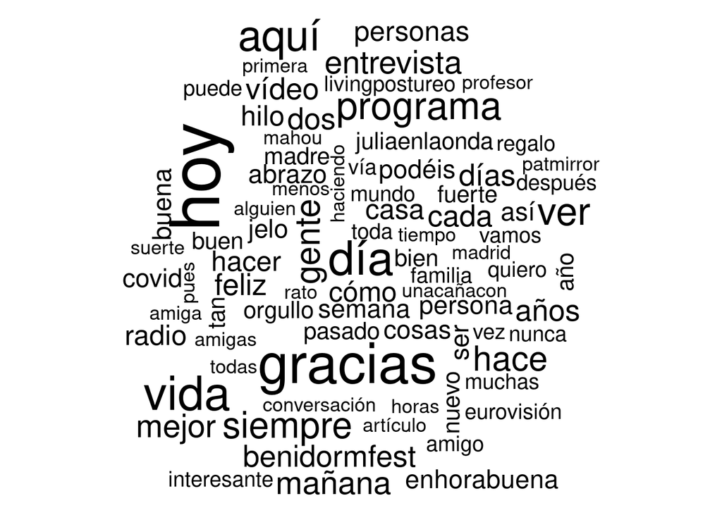

```r
wordFreqs=sort(colSums(as.matrix(documentTerm99)[,]),decreasing=TRUE)
wordcloud(words=names(wordFreqs),freq=wordFreqs)
```

#Machine learning

#Dataset preparation

In order to work with my dataset, it is first necessary to add a column to my doc-term matrix with the correct label, i.e. the user, for each tweet.

To do this, first to avoid possible mismatches of the matrix dimensions in the case of account owners adding tweets and on the recommendation of a colleague, I will set variables for the number of rows of the two initial data frames of a single user. these variables are the actual number of tweets taken into account from each user.

```r
#Set a variable for the number of rows for each
CarolinaRows = nrow(CarolinaTweetskeep)
JuliaRows = nrow(JuliaTweetskeep)
dim(documentTerm99) # 401  82
```

```
## [1] 401  82
```

```r
#Create "type"  vector
type=c(rep("Carolina",CarolinaRows),rep("Julia",JuliaRows))
documentTerm99=cbind(documentTerm99,type)
dim(documentTerm99) # 401  83
```

```
## [1] 401  83
```

```r
documentTermColumns = ncol(documentTerm99) #Set a variable for the number of columns
#Convert matrix and set the name for the last column "type"
documentTerm99.ML.matrix=as.data.frame(as.matrix(documentTerm99))
colnames(documentTerm99.ML.matrix)[documentTermColumns]="type"
dim(documentTerm99.ML.matrix) # 401  84
```

```
## [1] 401  83
```

```r
documentTermColumns = ncol(documentTerm99) #Set a variable for the number of columns
#Convert matrix and set the name for the last column "type"
documentTerm99.ML.matrix=as.data.frame(as.matrix(documentTerm99))
colnames(documentTerm99.ML.matrix)[documentTermColumns]="type"
#dim(documentTerm99.ML.matrix) # 401  84

documentTerm99.ML.matrix$type <- as.factor(documentTerm99.ML.matrix$type) # Code used to work around a bug explained below, just before testing the testing data with Naives Bayas.
documentTerm99.ML.matrix <- as.data.frame(sapply(documentTerm99.ML.matrix, as.numeric))
documentTerm99.ML.matrix[is.na(documentTerm99.ML.matrix)] <- 0
levels(documentTerm99.ML.matrix$type) <- c("Carolina", "Julia")
```

#Subsets of samples

It is necessary to partition train and test. The training dataset will be used to train the classifier, while the testing dataset will not be used for training, but will be used to assess the predictive ability of my classifier.

```r
library(caret)
set.seed(107) # a random seed to enable reproducibility
inTrain <- createDataPartition(y=documentTerm99.ML.matrix$type,p=.75,list=FALSE)
str(inTrain)
```

```
##  int [1:301, 1] 1 2 3 4 5 7 10 12 13 14 ...
##  - attr(*, "dimnames")=List of 2
##   ..$ : NULL
##   ..$ : chr "Resample1"
```

```r
training <- documentTerm99.ML.matrix[inTrain,]
testing <- documentTerm99.ML.matrix[-inTrain,]
nrow(training)
```

```
## [1] 301
```

#Training

Now I can start training and testing two different algorithms to obtain two supervised classification models, compare them and choose the one with the best results.

```r
#Setting the train performance control method and the metric
ctrl <- trainControl(method="cv", number = 10)
metric = "Accuracy"
```

```r
#Training with Naive-Bayes
#install.packages("naivebayes")
training$type <- as.factor(training$type) #code used to resolve the error at different levels
nbModel <- train(type ~ ., data=training,method="naive_bayes", tuneLength=10, trControl=ctrl , metric=metric)
nbModel
```

```
## Naive Bayes
##
## 301 samples
##  82 predictor
##   2 classes: '1', '2'
##
## No pre-processing
## Resampling: Cross-Validated (10 fold)
## Summary of sample sizes: 272, 270, 271, 270, 271, 271, ...
## Resampling results across tuning parameters:
##
##   usekernel  Accuracy   Kappa
##   FALSE      0.4843938  -0.01271119
##    TRUE      0.5116203   0.00000000
##
## Tuning parameter 'laplace' was held constant at a value of 0
## Tuning
##  parameter 'adjust' was held constant at a value of 1
## Accuracy was used to select the optimal model using the largest value.
## The final values used for the model were laplace = 0, usekernel = TRUE
##  and adjust = 1.
```

```r
#levels(training$abrazo)
#view(training)
```

At this point I found when I tried testing the following error: “factor abrazo has new levels 2”. I tried to solve it in different ways, when I saw that it didn’t work I asked a colleague and he recommended me first to change the amount of tweets I was working with(1000). First I tried with 1500 and then with 2000, but with 1500 I got the same error and with 2000 I got the following error: “factor buen has new levels 2”. In the end he recommended me to change my confusion matrix with the help of the code he provided, which helped to solve the error perfectly.

```r
#testing$abrazo <- NULL
#str(testing)
nbModelClasses <- predict(nbModel, newdata = testing, type = "raw")
confusionMatrix(data=nbModelClasses,as.factor(testing$type))
```

```
## Confusion Matrix and Statistics
##
##           Reference
## Prediction  1  2
##          1 61 39
##          2  0  0
##
##                Accuracy : 0.61
##                  95% CI : (0.5073, 0.706)
##     No Information Rate : 0.61
##     P-Value [Acc > NIR] : 0.5438
##
##                   Kappa : 0
##
##  Mcnemar's Test P-Value : 1.166e-09
##
##             Sensitivity : 1.00
##             Specificity : 0.00
##          Pos Pred Value : 0.61
##          Neg Pred Value :  NaN
##              Prevalence : 0.61
##          Detection Rate : 0.61
##    Detection Prevalence : 1.00
##       Balanced Accuracy : 0.50
##
##        'Positive' Class : 1
##
```

```r
#str(training)
```

```r
#Training with Random Forest
library(randomForest)
rfModelcv <- train(type ~ ., data=training,method="rf", tuneLength=10, trControl=ctrl , metric=metric)
rfModelcv
```

```
## Random Forest
##
## 301 samples
##  82 predictor
##   2 classes: '1', '2'
##
## No pre-processing
## Resampling: Cross-Validated (10 fold)
## Summary of sample sizes: 270, 270, 272, 270, 272, 272, ...
## Resampling results across tuning parameters:
##
##   mtry  Accuracy   Kappa
##    2    0.5947868  0.1808362
##   10    0.5811161  0.1577346
##   19    0.5882277  0.1756220
##   28    0.5881275  0.1756716
##   37    0.5882351  0.1737144
##   46    0.5847868  0.1685983
##   55    0.5877901  0.1720284
##   64    0.5844568  0.1699310
##   73    0.5781201  0.1551008
##   82    0.5847868  0.1680862
##
## Accuracy was used to select the optimal model using the largest value.
## The final value used for the model was mtry = 2.
```

```r
rfModelClasses <- predict(rfModelcv, newdata = testing, type = "raw")
confusionMatrix(data=rfModelClasses,as.factor(testing$type))
```

```
## Confusion Matrix and Statistics
##
##           Reference
## Prediction  1  2
##          1 34 10
##          2 27 29
##
##                Accuracy : 0.63
##                  95% CI : (0.5276, 0.7244)
##     No Information Rate : 0.61
##     P-Value [Acc > NIR] : 0.381920
##
##                   Kappa : 0.279
##
##  Mcnemar's Test P-Value : 0.008529
##
##             Sensitivity : 0.5574
##             Specificity : 0.7436
##          Pos Pred Value : 0.7727
##          Neg Pred Value : 0.5179
##              Prevalence : 0.6100
##          Detection Rate : 0.3400
##    Detection Prevalence : 0.4400
##       Balanced Accuracy : 0.6505
##
##        'Positive' Class : 1
##
```

```r
resamps=resamples(list(nb=nbModel,rf=rfModelcv))
summary(resamps)
```

```
##
## Call:
## summary.resamples(object = resamps)
##
## Models: nb, rf
## Number of resamples: 10
##
## Accuracy
##         Min.   1st Qu.   Median      Mean   3rd Qu.      Max. NA's
## nb 0.5000000 0.5000000 0.516129 0.5116203 0.5169633 0.5333333    0
## rf 0.5333333 0.5589544 0.583426 0.5947868 0.6187430 0.6666667    0
##
## Kappa
##          Min.   1st Qu.    Median      Mean   3rd Qu.      Max. NA's
## nb 0.00000000 0.0000000 0.0000000 0.0000000 0.0000000 0.0000000    0
## rf 0.06666667 0.1189671 0.1539176 0.1808362 0.2191653 0.3333333    0
```

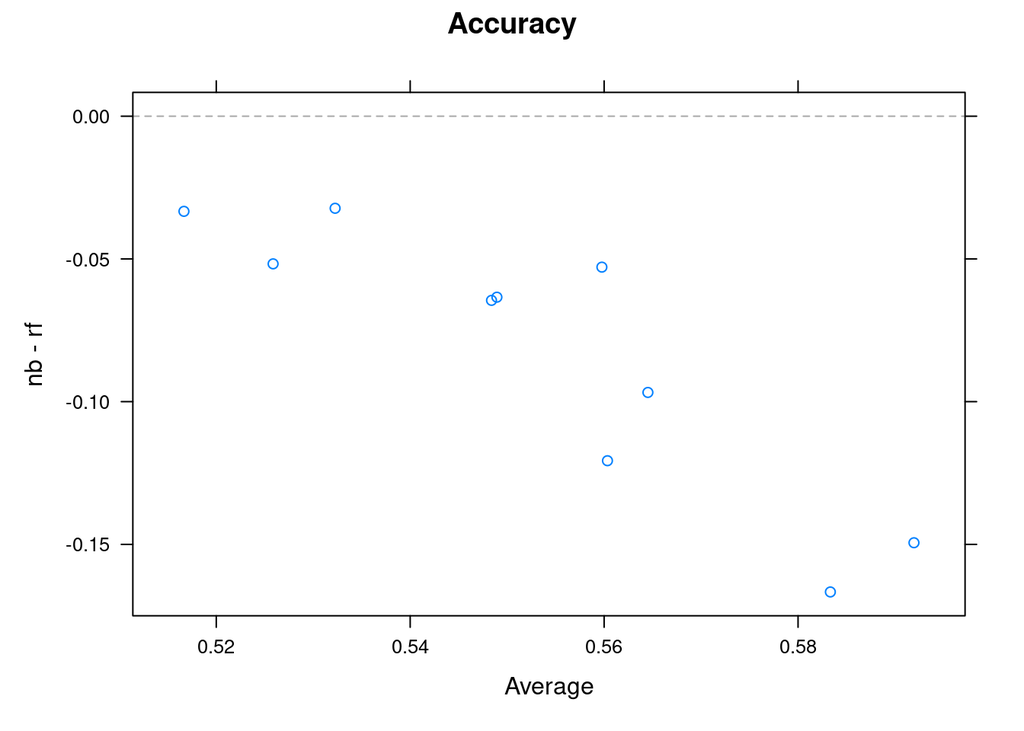

```r
xyplot(resamps,what="BlandAltman")
```

```r
diffs<-diff(resamps)
summary(diffs)
```

```
##
## Call:
## summary.diff.resamples(object = diffs)
##
## p-value adjustment: bonferroni
## Upper diagonal: estimates of the difference
## Lower diagonal: p-value for H0: difference = 0
##
## Accuracy
##    nb        rf
## nb           -0.08317
## rf 0.0003866
##
## Kappa
##    nb        rf
## nb           -0.1808
## rf 0.0001761
```

#Conclusions

Therefore, it can be stated that Random Forest has been more effective than Naives Bayes.